# International Cherry Blossom Prediction Competition

$$AGDD_i = \sum_{t_0}^{t_{\gamma-1}} GDD_i$$

```r
# ---- Predictors ----

## Fixed ----
data_predictors_fixed <-
  df_bloom_complete |>
  distinct(lat, long, .keep_all = TRUE) |>
  select(-c(location, year, bloom_date, bloom_doy, shrubs, id_coord)) |>
  distinct(lat, long, .keep_all = TRUE) |>
  janitor::clean_names()

write_parquet(data_predictors_fixed,
              "../external-data/data-models/data_predictors_fixed.parquet")

## Summary predictors with climate ----
options(future.globals.maxSize= 1000*1024^2) # Config furrr
plan(multisession, workers = parallel::detectCores() - 2)

### 1 Month ----
number_months_weather <- 1

data_predictors_summary_weather1M <-
  FEWeatherSummary(
    months_window = number_months_weather,
    data_bloom = df_bloom_complete,
    data_weather = df_weather
  )

write_parquet(data_predictors_summary_weather1M,
              "../external-data/data-models/data_predictors_summary_weather1M.parquet")

### 3 Months ----
number_months_weather <- 3

data_predictors_summary_weather3M <-
  FEWeatherSummary(
    months_window = number_months_weather,
    data_bloom = df_bloom_complete,
    data_weather = df_weather
  )

write_parquet(data_predictors_summary_weather3M,
              "../external-data/data-models/data_predictors_summary_weather3M.parquet")

### 6 Months ----
number_months_weather <- 6

data_predictors_summary_weather6M <-
  FEWeatherSummary(
    months_window = number_months_weather,
    data_bloom = df_bloom_complete,
    data_weather = df_weather
  )

write_parquet(data_predictors_summary_weather6M,
              "../external-data/data-models/data_predictors_summary_weather6M.parquet")

### 9 Months ----
number_months_weather <- 9

data_predictors_summary_weather9M <-
  FEWeatherSummary(
    months_window = number_months_weather,
    data_bloom = df_bloom_complete,
    data_weather = df_weather
  )

write_parquet(data_predictors_summary_weather9M,
              "../external-data/data-models/data_predictors_summary_weather9M.parquet")

### 12 Months ----
number_months_weather <- 12

data_predictors_summary_weather12M <-
  FEWeatherSummary(
    months_window = number_months_weather,
    data_bloom = df_bloom_complete,
    data_weather = df_weather
  )

write_parquet(data_predictors_summary_weather12M,
              "../external-data/data-models/data_predictors_summary_weather12M.parquet")

## Summary predictors with photoperiod ----
options(future.globals.maxSize= 1000*1024^2) # Config furrr
plan(multisession, workers = parallel::detectCores() - 2)

### 1 Month ----
number_months_photo <- 1

data_predictors_summary_photo1M <-
  FEPhotopSummary(months_window = number_months_photo,
                  data_bloom = df_bloom_complete,
                  data_photo = df_photoperiod)

write_parquet(
  data_predictors_summary_photo1M,
  "../external-data/data-models/data_predictors_summary_photo1M.parquet"
)

### 3 Months ----
number_months_photo <- 3

data_predictors_summary_photo3M <-
  FEPhotopSummary(months_window = number_months_photo,
                  data_bloom = df_bloom_complete,
                  data_photo = df_photoperiod)

write_parquet(
  data_predictors_summary_photo3M,
  "../external-data/data-models/data_predictors_summary_photo3M.parquet"
)

### 6 Months ----
number_months_photo <- 6

data_predictors_summary_photo6M <-
  FEPhotopSummary(months_window = number_months_photo,
                  data_bloom = df_bloom_complete,
                  data_photo = df_photoperiod)

write_parquet(
  data_predictors_summary_photo6M,
  "../external-data/data-models/data_predictors_summary_photo6M.parquet"
)

### 9 Months ----
number_months_photo <- 9

data_predictors_summary_photo9M <-
  FEPhotopSummary(months_window = number_months_photo,
                  data_bloom = df_bloom_complete,
                  data_photo = df_photoperiod)

write_parquet(
  data_predictors_summary_photo9M,
  "../external-data/data-models/data_predictors_summary_photo9M.parquet"
)

### 12 Months ----
number_months_photo <- 12

data_predictors_summary_photo12M <-
  FEPhotopSummary(months_window = number_months_photo,
                  data_bloom = df_bloom_complete,
                  data_photo = df_photoperiod)

write_parquet(
  data_predictors_summary_photo12M,
  "../external-data/data-models/data_predictors_summary_photo12M.parquet"
)

## Summary predictors with weather (GDD) ----
options(future.globals.maxSize = 1000 * 1024 ^ 2) # Config furrr
plan(multisession, workers = parallel::detectCores() - 2)

data_predictors_GDD <-
  featureEngGDD(
    start_date = "01-01", # MMDD
    t_basal = 5, # °C
    data_bloom = df_bloom_complete,
    data_weather = df_weather
  )

write_parquet(data_predictors_GDD,
              "../external-data/data-models/data_predictors_GDD.parquet")
```

# Complete data: modeling

- I join the databases `data_predictors_fixed`, `data_predictors_summary_weather[w]M`, `data_predictors_summary_photo[w]M` and `data_predictors_gdd`. This is the final database for model building.
- The final table has 10,118 rows and 241 columns, of which 234 are predictors generated with fixed information (bioclimatic, coverage, etc.), meteorological, photoperiod and GDD. The other 7 columns are identifiers such as country, location, among others. This table has the response variable `bloom_doy` in a year $t$ and all the predictors were obtained with information prior to the event of interest.

```r
# Auxiliar function ----
extract_number <- function(text) {
  match <- gregexpr("\\d+", text)
  number <- regmatches(text, match)
  number <- as.integer(number)
  return(number)
}

# =================== PREDICTORS =========================================

# Import data: 36 predictors ----
data_predictors_fixed <-
  read_parquet("../external-data/data-models/data_predictors_fixed.parquet")

## Weather: 180 predictors ----
data_predictors_summary_weather <-
  fs::dir_ls("../external-data/data-models/", regexp = "summary_weather") |>
  map(
    .f = function(x = .x) {
      read_parquet(x) |>
        mutate(month_weather = str_c("month_", extract_number(x)))
    }
  ) |>
  list_rbind() |>
  pivot_wider(
    names_from = month_weather,
    values_from = -c(lat, long, month_weather, year_bloom)
  ) |>
  unnest() |>
  distinct_all()

## Photoperiod: 15 predictors ----
data_predictors_summary_photo <-
  fs::dir_ls("../external-data/data-models/", regexp = "summary_photo") |>
  map(
    .f = function(x = .x) {
      read_parquet(x) |>
        mutate(month_photo = str_c("month_", extract_number(x)))
    }
  ) |>
  list_rbind() |>
  pivot_wider(
    names_from = month_photo,
    values_from = -c(lat, month_photo, year_bloom)
  ) |>
  unnest() |>
  distinct_all()

## AGDD: 3 predictors ----
data_predictors_gdd <-
  read_parquet("../external-data/data-models/data_predictors_GDD.parquet")

# =================== TARGET =========================================
data_modeling <-
  df_bloom_complete |>
  select(location, lat, long, year_bloom = year, bloom_doy) |>
  left_join(data_predictors_fixed, by = c("lat", "long")) |>
  left_join(data_predictors_summary_weather,
            by = c("lat", "long", "year_bloom")) |>
  left_join(data_predictors_summary_photo, by = c("lat", "year_bloom")) |>
  left_join(data_predictors_gdd, by = c("lat", "long", "year_bloom")) |>
  relocate(location, country, everything()) |>
  distinct(lat, long, year_bloom, .keep_all = TRUE)

write_parquet(data_modeling,
              "../external-data/data-models/data_modeling.parquet")
```

# Predictors vs Target

## AGDD vs DOY

- With these graphs I not only intend to observe the relationship between AGDD and the DOY but also validate whether the three equations proposed to calculate the GDD disagree with each other.

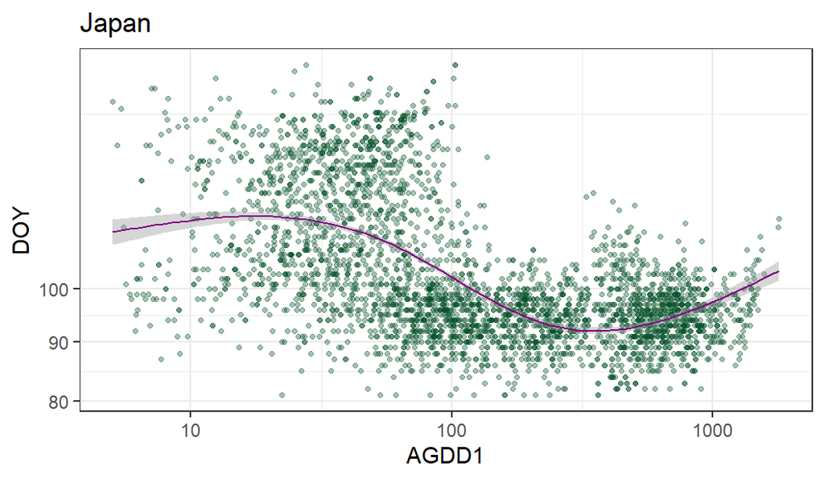

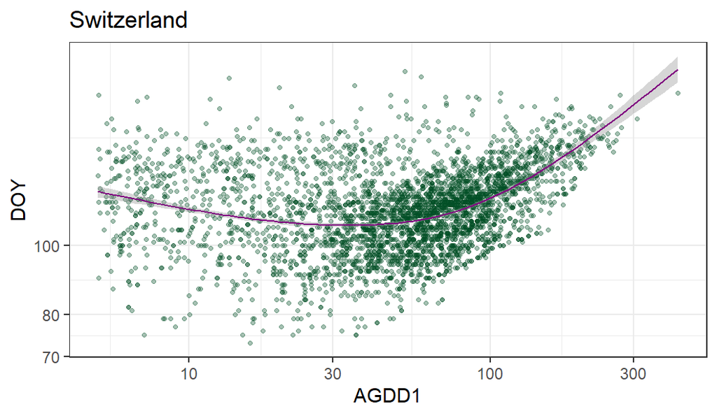

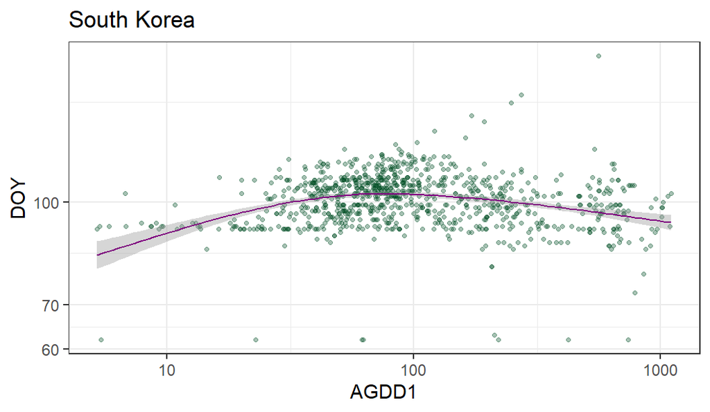

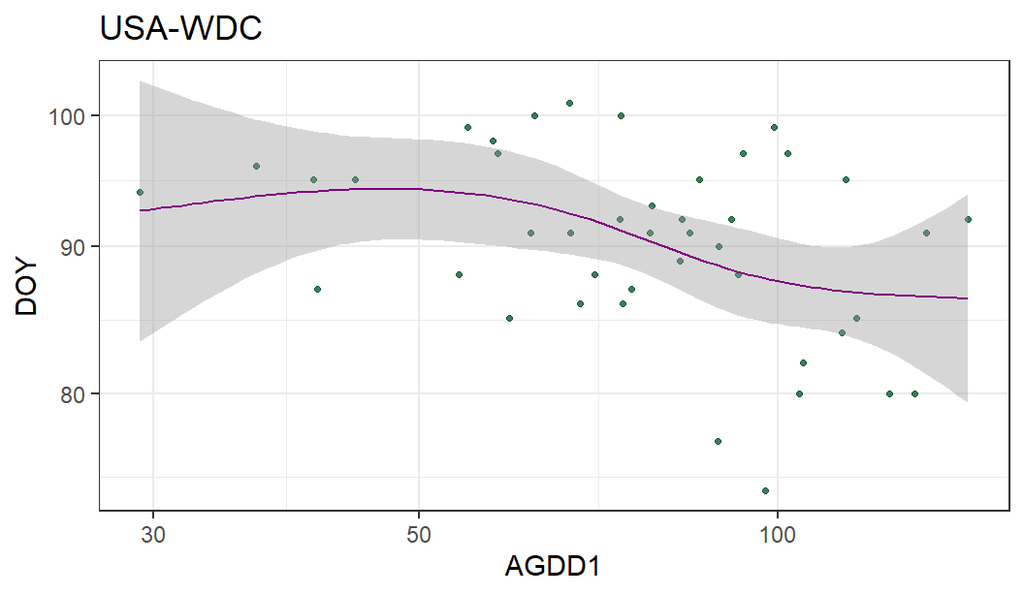

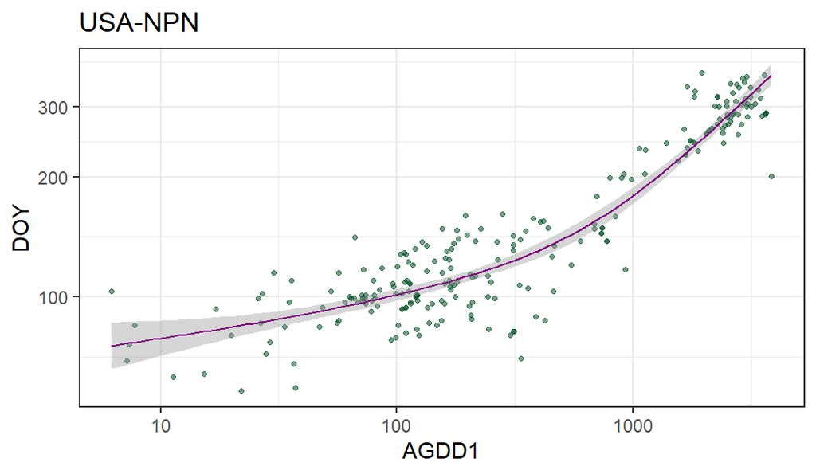

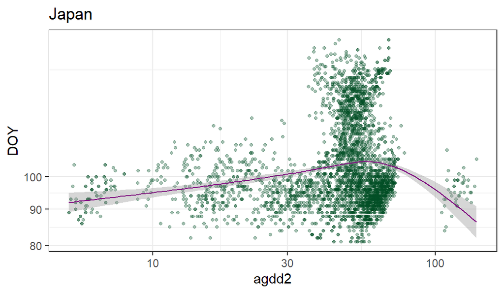

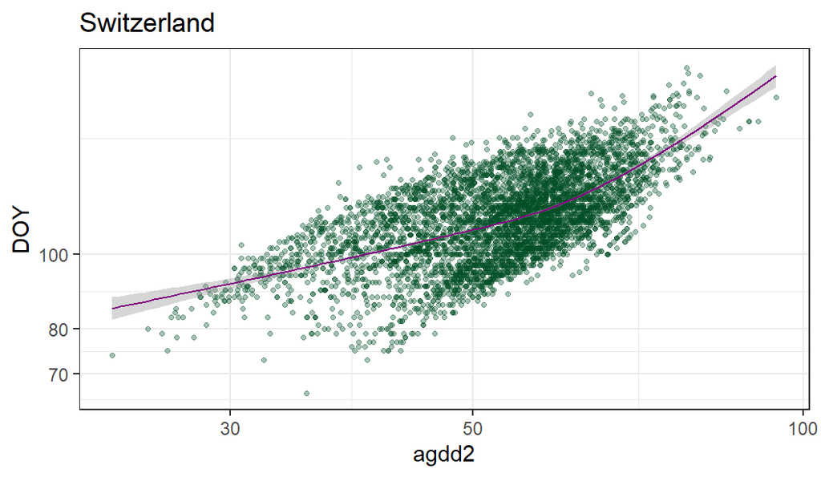

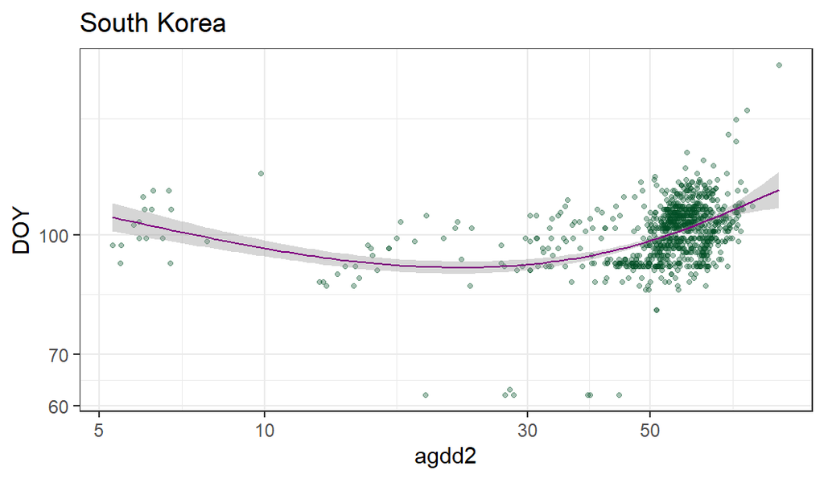

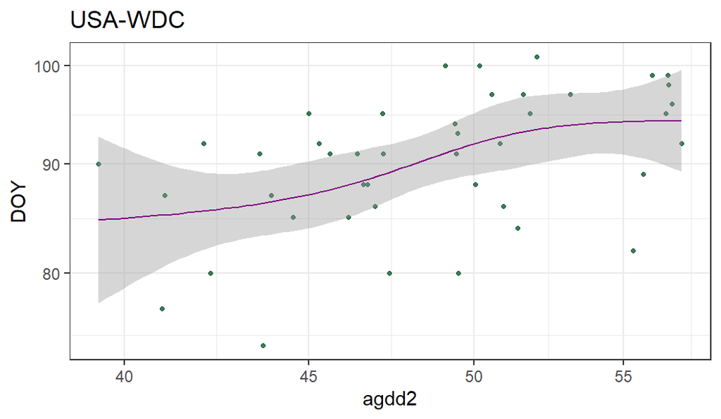

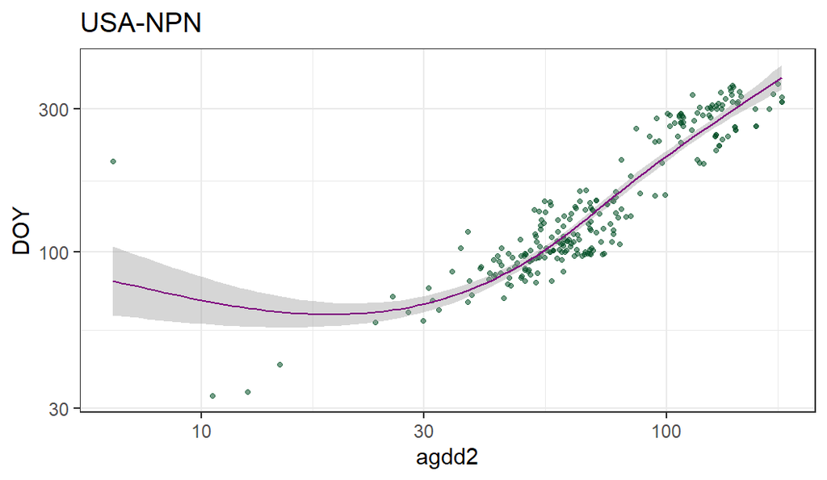

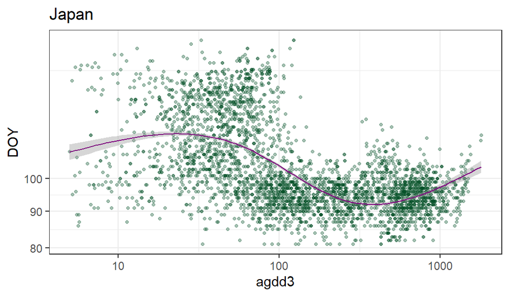

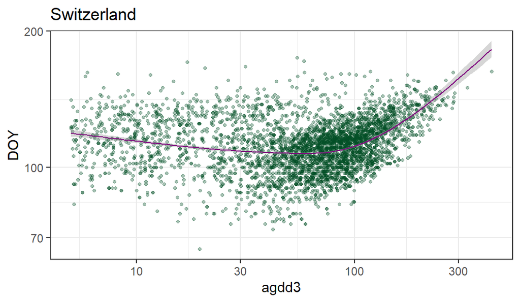

[3 more figures not shown]

```r
data_modeling <-
  read_parquet("../external-data/data-models/data_modeling.parquet") |>
  mutate(lat = round(lat, 4),
         long = round(long, 4))

data_coords_predict <-
  read_parquet("../external-data/data-models/df_coords_predict.parquet") |>
  mutate(lat = round(lat, 4),
         long = round(long, 4))

location_predict <- data_coords_predict$location_name

lat_predict <-
  data_coords_predict$lat

long_predict <-
  data_coords_predict$long


names_location <-
  unique(data_modeling$location)

names_country <-
  unique(data_modeling$country)


# Plots AGDD1 ----
data_modeling |>
  filter(country == names_country[1]) |>
  filter(agdd1 > 5) |>
  filter(bloom_doy > 80) |>
  ggplot(aes(x = agdd1, y = bloom_doy)) +
  geom_point(color = colors_custom[1],
             alpha = 0.35,
             size = 0.85) +
  geom_smooth(
      method = "gam",
      formula = y ~ ns(x, df = 3),
      color = colors_custom[2],
      size = 0.5
    ) +
  scale_x_log10() +
  scale_y_log10() +
  labs(title = names_country[1],
       x = "AGDD1",
       y = "DOY")
data_modeling |>
  filter(country == names_country[2]) |>
  filter(agdd1 > 5) |>
  ggplot(aes(x = agdd1, y = bloom_doy)) +
  geom_point(color = colors_custom[1],
             alpha = 0.35,
             size = 0.85) +
  geom_smooth(
      method = "gam",
      formula = y ~ ns(x, df = 3),
      color = colors_custom[2],
      size = 0.5
    ) +
  scale_x_log10() +
  scale_y_log10() +
  labs(title = names_country[2],
       x = "AGDD1",
       y = "DOY")
data_modeling |>
  filter(country == names_country[3]) |>
  filter(agdd1 > 5) |>
  ggplot(aes(x = agdd1, y = bloom_doy)) +
  geom_point(color = colors_custom[1],
             alpha = 0.35,
             size = 0.85) +
  geom_smooth(
      method = "gam",
      formula = y ~ ns(x, df = 3),
      color = colors_custom[2],
      size = 0.5
    ) +
  scale_x_log10() +
  scale_y_log10() +
  labs(title = names_country[3],
       x = "AGDD1",
       y = "DOY")
data_modeling |>
  filter(country == names_country[5]) |>
  filter(agdd1 > 5) |>
  ggplot(aes(x = agdd1, y = bloom_doy)) +
  geom_point(color = colors_custom[1],
             alpha = 0.75,
             size = 0.85) +
  geom_smooth(
      method = "gam",
      formula = y ~ ns(x, df = 3),
      color = colors_custom[2],
      size = 0.5
    ) +
  scale_x_log10() +
  scale_y_log10() +
  labs(title = names_country[5],
       x = "AGDD1",
       y = "DOY")
data_modeling |>
  filter(country == names_country[6]) |>
  filter(agdd1 > 5) |>
  ggplot(aes(x = agdd1, y = bloom_doy)) +
  geom_point(color = colors_custom[1],
             alpha = 0.55,
             size = 0.85) +
  geom_smooth(
      method = "gam",
      formula = y ~ ns(x, df = 3),
      color = colors_custom[2],
      size = 0.5
    ) +
  scale_x_log10() +
  scale_y_log10() +
  labs(title = names_country[6],
       x = "AGDD1",
       y = "DOY")
# Plots AGDD2 ----
data_modeling |>
  filter(country == names_country[1]) |>
  filter(agdd2 > 5) |>
  filter(bloom_doy > 80) |>
  ggplot(aes(x = agdd2, y = bloom_doy)) +
  geom_point(color = colors_custom[1],
             alpha = 0.35,
             size = 0.85) +
  geom_smooth(
    method = "gam",
    formula = y ~ ns(x, df = 3),
    color = colors_custom[2],
    size = 0.5
  ) +
  scale_x_log10() +
  scale_y_log10() +
  labs(title = names_country[1],
       x = "agdd2",
       y = "DOY")
data_modeling |>
  filter(country == names_country[2]) |>
  filter(agdd2 > 5) |>
  ggplot(aes(x = agdd2, y = bloom_doy)) +
  geom_point(color = colors_custom[1],
             alpha = 0.35,
             size = 0.85) +
  geom_smooth(
    method = "gam",
    formula = y ~ ns(x, df = 3),
    color = colors_custom[2],
    size = 0.5
  ) +
  scale_x_log10() +
  scale_y_log10() +
  labs(title = names_country[2],
       x = "agdd2",
       y = "DOY")
data_modeling |>
  filter(country == names_country[3]) |>
  filter(agdd2 > 5) |>
  ggplot(aes(x = agdd2, y = bloom_doy)) +
  geom_point(color = colors_custom[1],
             alpha = 0.35,
             size = 0.85) +
  geom_smooth(
    method = "gam",
    formula = y ~ ns(x, df = 3),
    color = colors_custom[2],
    size = 0.5
  ) +
  scale_x_log10() +
  scale_y_log10() +
  labs(title = names_country[3],
       x = "agdd2",
       y = "DOY")
data_modeling |>
  filter(country == names_country[5]) |>
  filter(agdd2 > 5) |>
  ggplot(aes(x = agdd2, y = bloom_doy)) +
  geom_point(color = colors_custom[1],
             alpha = 0.75,
             size = 0.85) +
  geom_smooth(
    method = "gam",
    formula = y ~ ns(x, df = 3),
    color = colors_custom[2],
    size = 0.5
  ) +
  scale_x_log10() +
  scale_y_log10() +
  labs(title = names_country[5],
       x = "agdd2",
       y = "DOY")
data_modeling |>
  filter(country == names_country[6]) |>
  filter(agdd2 > 5) |>
  ggplot(aes(x = agdd2, y = bloom_doy)) +
  geom_point(color = colors_custom[1],
             alpha = 0.55,
             size = 0.85) +
  geom_smooth(
    method = "gam",
    formula = y ~ ns(x, df = 3),
    color = colors_custom[2],
    size = 0.5
  ) +
  scale_x_log10() +
  scale_y_log10() +
  labs(title = names_country[6],
       x = "agdd2",
       y = "DOY")
# Plots AGDD3 ----
data_modeling |>
  filter(country == names_country[1]) |>
  filter(agdd3 > 5) |>
  filter(bloom_doy > 80) |>
  ggplot(aes(x = agdd3, y = bloom_doy)) +
  geom_point(color = colors_custom[1],
             alpha = 0.35,
             size = 0.85) +
  geom_smooth(
    method = "gam",
    formula = y ~ ns(x, df = 3),
    color = colors_custom[2],
    size = 0.5
  ) +
  scale_x_log10() +
  scale_y_log10() +
  labs(title = names_country[1],
       x = "agdd3",
       y = "DOY")
data_modeling |>
  filter(country == names_country[2]) |>
  filter(agdd3 > 5) |>
  ggplot(aes(x = agdd3, y = bloom_doy)) +
  geom_point(color = colors_custom[1],
             alpha = 0.35,
             size = 0.85) +
  geom_smooth(
    method = "gam",
    formula = y ~ ns(x, df = 3),
    color = colors_custom[2],
    size = 0.5
  ) +
  scale_x_log10() +
  scale_y_log10() +
  labs(title = names_country[2],
       x = "agdd3",
       y = "DOY")
data_modeling |>
  filter(country == names_country[3]) |>
  filter(agdd3 > 5) |>
  ggplot(aes(x = agdd3, y = bloom_doy)) +
  geom_point(color = colors_custom[1],
             alpha = 0.35,
             size = 0.85) +
  geom_smooth(
    method = "gam",
    formula = y ~ ns(x, df = 3),
    color = colors_custom[2],
    size = 0.5
  ) +
  scale_x_log10() +
  scale_y_log10() +
  labs(title = names_country[3],
       x = "agdd3",
       y = "DOY")
data_modeling |>
  filter(country == names_country[5]) |>
  filter(agdd3 > 5) |>
  ggplot(aes(x = agdd3, y = bloom_doy)) +
  geom_point(color = colors_custom[1],
             alpha = 0.75,
             size = 0.85) +
  geom_smooth(
    method = "gam",
    formula = y ~ ns(x, df = 3),
    color = colors_custom[2],
    size = 0.5
  ) +
  scale_x_log10() +
  scale_y_log10() +
  labs(title = names_country[5],
       x = "agdd3",
       y = "DOY")
data_modeling |>
  filter(country == names_country[6]) |>
  filter(agdd3 > 5) |>
  ggplot(aes(x = agdd3, y = bloom_doy)) +
  geom_point(color = colors_custom[1],
             alpha = 0.55,
             size = 0.85) +
  geom_smooth(
    method = "gam",
    formula = y ~ ns(x, df = 3),
    color = colors_custom[2],
    size = 0.5
  ) +
  scale_x_log10() +
  scale_y_log10() +
  labs(title = names_country[6],
       x = "agdd3",
       y = "DOY")
```

## Precipitation/Evaporation (last quarter before flowering) vs DOY

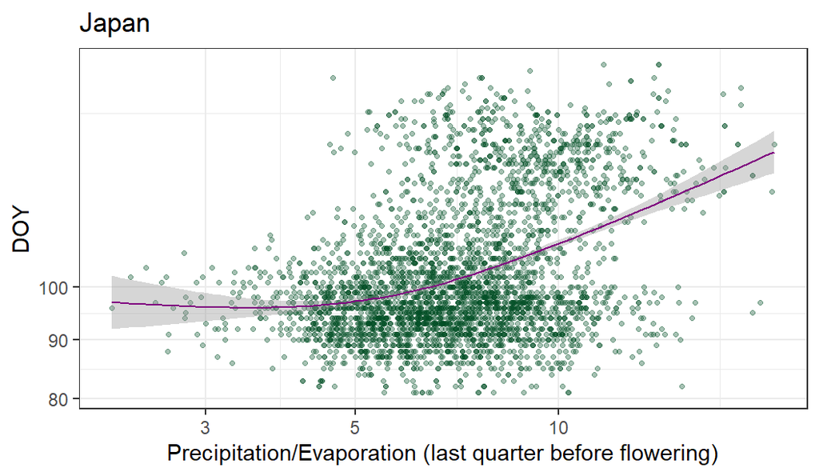

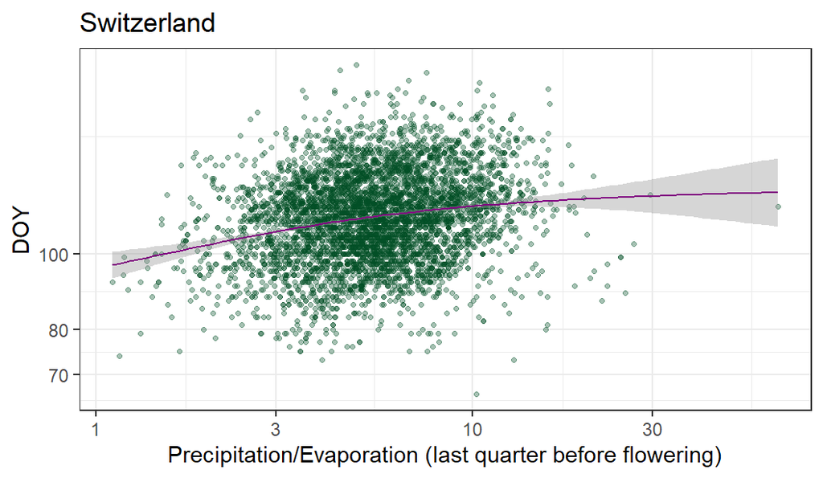

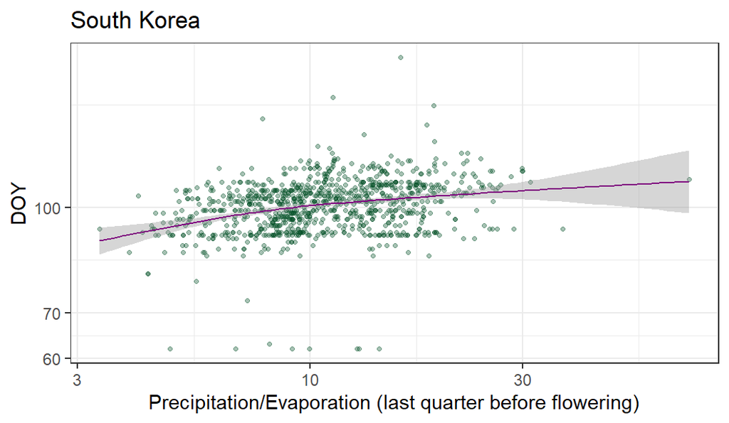

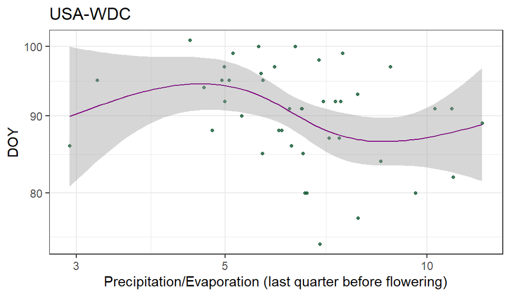

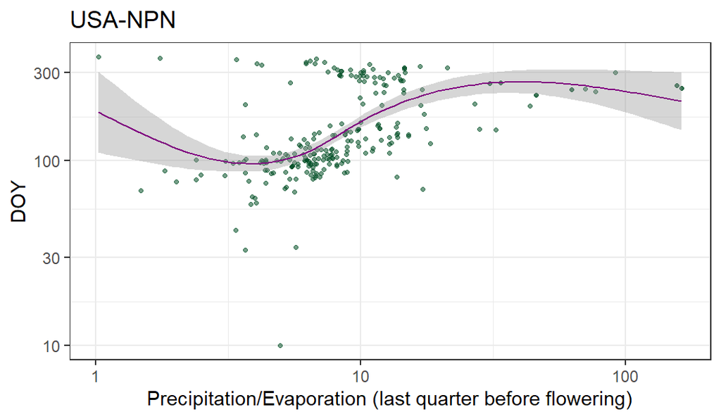

```r
data_modeling |>
  filter(country == names_country[1]) |>
  # filter(rate_acumm_precip_evap_month_3 > 5) |>
  filter(bloom_doy > 80) |>
  ggplot(aes(x = rate_acumm_precip_evap_month_3, y = bloom_doy)) +
  geom_point(color = colors_custom[1],
             alpha = 0.35,
             size = 0.85) +
  geom_smooth(
    method = "gam",
    formula = y ~ ns(x, df = 3),
    color = colors_custom[2],
    size = 0.5
  ) +
  scale_x_log10() +
  scale_y_log10() +
  labs(title = names_country[1],
       x = "Precipitation/Evaporation (last quarter before flowering)",
       y = "DOY")
data_modeling |>
  filter(country == names_country[2]) |>
  # filter(rate_acumm_precip_evap_month_3 > 5) |>
  ggplot(aes(x = rate_acumm_precip_evap_month_3, y = bloom_doy)) +
  geom_point(color = colors_custom[1],
             alpha = 0.35,
             size = 0.85) +
  geom_smooth(
    method = "gam",
    formula = y ~ ns(x, df = 3),
    color = colors_custom[2],
    size = 0.5
  ) +
  scale_x_log10() +
  scale_y_log10() +
  labs(title = names_country[2],
       x = "Precipitation/Evaporation (last quarter before flowering)",
       y = "DOY")
data_modeling |>
  filter(country == names_country[3]) |>
  # filter(rate_acumm_precip_evap_month_3 > 5) |>
  ggplot(aes(x = rate_acumm_precip_evap_month_3, y = bloom_doy)) +
  geom_point(color = colors_custom[1],
             alpha = 0.35,
             size = 0.85) +
  geom_smooth(
    method = "gam",
    formula = y ~ ns(x, df = 3),
    color = colors_custom[2],
    size = 0.5
  ) +
  scale_x_log10() +
  scale_y_log10() +
  labs(title = names_country[3],
       x = "Precipitation/Evaporation (last quarter before flowering)",
       y = "DOY")
data_modeling |>
  filter(country == names_country[5]) |>
  # filter(rate_acumm_precip_evap_month_3 > 5) |>
  ggplot(aes(x = rate_acumm_precip_evap_month_3, y = bloom_doy)) +
  geom_point(color = colors_custom[1],
             alpha = 0.75,
             size = 0.85) +
  geom_smooth(
    method = "gam",
    formula = y ~ ns(x, df = 3),
    color = colors_custom[2],
    size = 0.5
  ) +
  scale_x_log10() +
  scale_y_log10() +
  labs(title = names_country[5],
       x = "Precipitation/Evaporation (last quarter before flowering)",
       y = "DOY")
data_modeling |>
  filter(country == names_country[6]) |>
  # filter(rate_acumm_precip_evap_month_3 > 5) |>
  ggplot(aes(x = rate_acumm_precip_evap_month_3, y = bloom_doy)) +
  geom_point(color = colors_custom[1],
             alpha = 0.55,
             size = 0.85) +
  geom_smooth(
    method = "gam",
    formula = y ~ ns(x, df = 3),
    color = colors_custom[2],
    size = 0.5
  ) +
  scale_x_log10() +
  scale_y_log10() +
  labs(title = names_country[6],
       x = "Precipitation/Evaporation (last quarter before flowering)",
       y = "DOY")
```

## Frost days (last quarter before flowering)

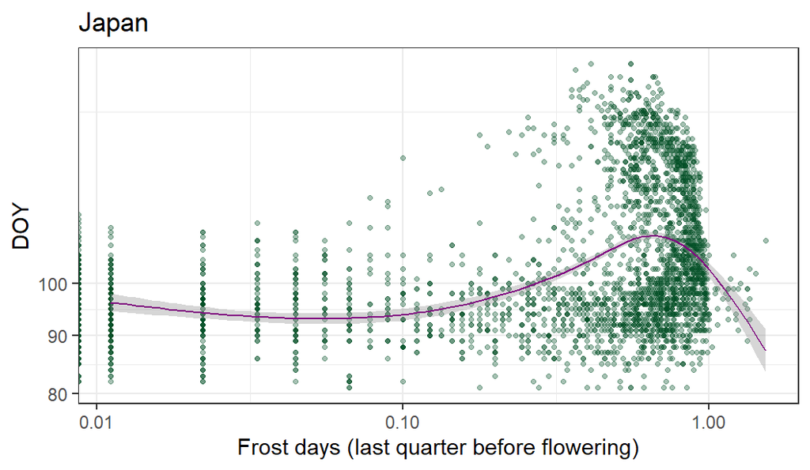

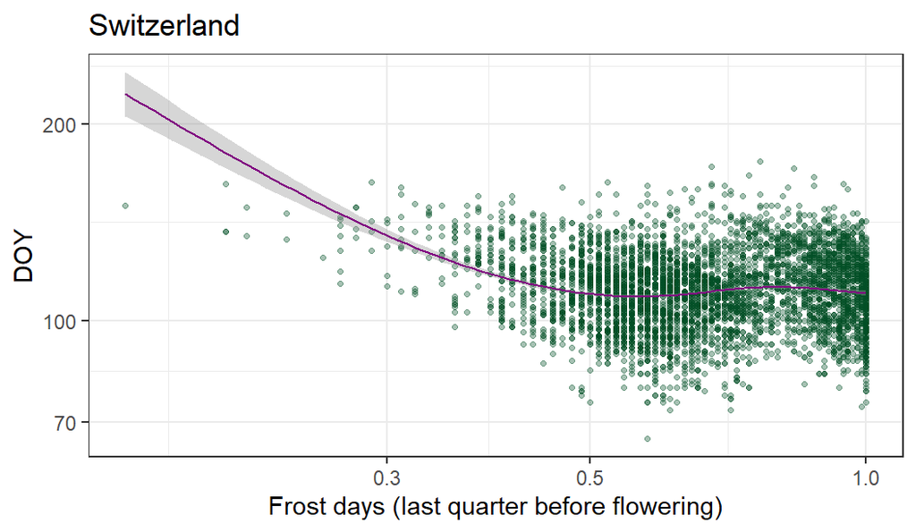

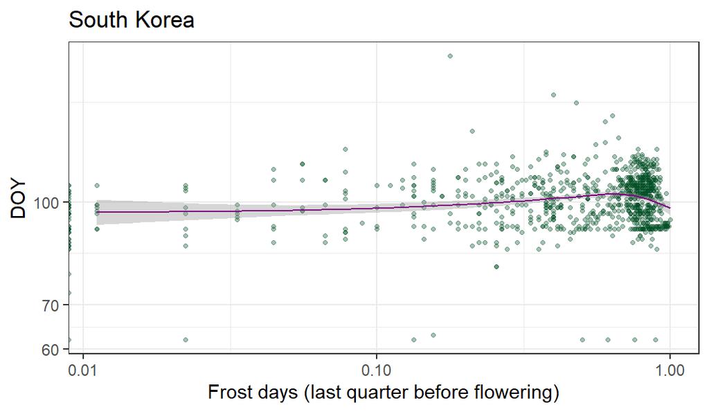

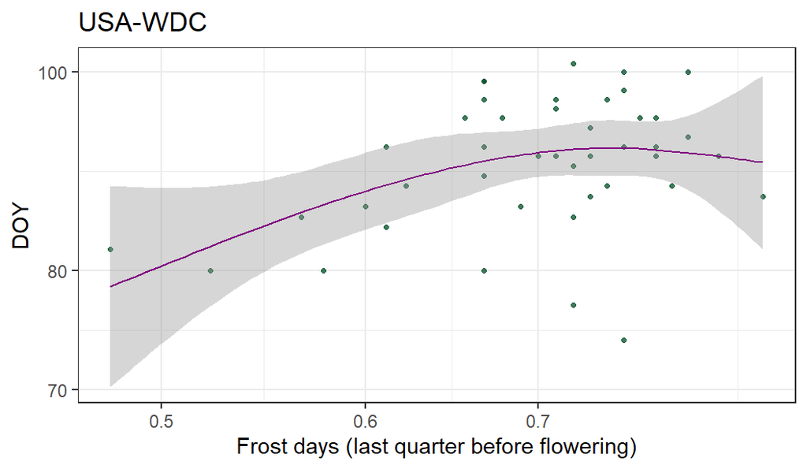

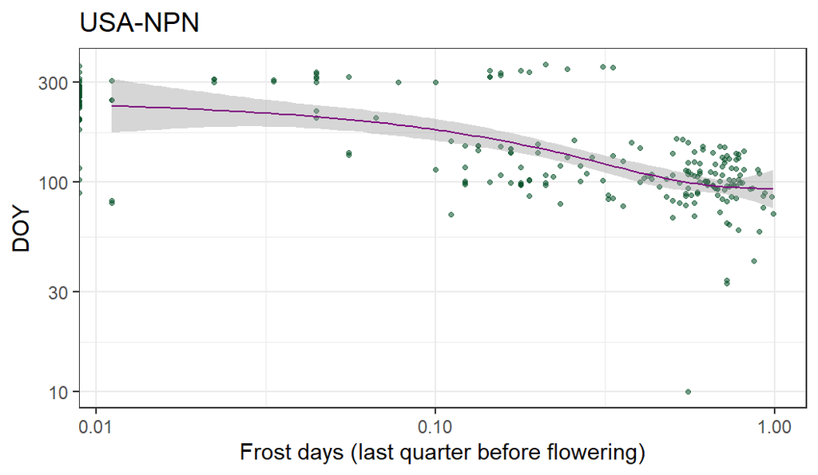

```r
data_modeling |>
  filter(country == names_country[1]) |>
  # filter(prop_frost_days1_month_3 > 5) |>
  filter(bloom_doy > 80) |>
  ggplot(aes(x = prop_frost_days1_month_3, y = bloom_doy)) +
  geom_point(color = colors_custom[1],
             alpha = 0.35,
             size = 0.85) +
  geom_smooth(
    method = "gam",
    formula = y ~ ns(x, df = 3),
    color = colors_custom[2],
    size = 0.5
  ) +
  scale_x_log10() +
  scale_y_log10() +
  labs(title = names_country[1],
       x = "Frost days (last quarter before flowering)",
       y = "DOY")
data_modeling |>
  filter(country == names_country[2]) |>
  # filter(prop_frost_days1_month_3 > 5) |>
  ggplot(aes(x = prop_frost_days1_month_3, y = bloom_doy)) +
  geom_point(color = colors_custom[1],
             alpha = 0.35,
             size = 0.85) +
  geom_smooth(
    method = "gam",
    formula = y ~ ns(x, df = 3),
    color = colors_custom[2],
    size = 0.5
  ) +
  scale_x_log10() +
  scale_y_log10() +
  labs(title = names_country[2],
       x = "Frost days (last quarter before flowering)",
       y = "DOY")
data_modeling |>
  filter(country == names_country[3]) |>
  # filter(prop_frost_days1_month_3 > 5) |>
  ggplot(aes(x = prop_frost_days1_month_3, y = bloom_doy)) +
  geom_point(color = colors_custom[1],
             alpha = 0.35,
             size = 0.85) +
  geom_smooth(
    method = "gam",
    formula = y ~ ns(x, df = 3),
    color = colors_custom[2],
    size = 0.5
  ) +
  scale_x_log10() +
  scale_y_log10() +
  labs(title = names_country[3],
       x = "Frost days (last quarter before flowering)",
       y = "DOY")
data_modeling |>
  filter(country == names_country[5]) |>
  # filter(prop_frost_days1_month_3 > 5) |>
  ggplot(aes(x = prop_frost_days1_month_3, y = bloom_doy)) +
  geom_point(color = colors_custom[1],
             alpha = 0.75,
             size = 0.85) +
  geom_smooth(
    method = "gam",
    formula = y ~ ns(x, df = 3),
    color = colors_custom[2],
    size = 0.5
  ) +
  scale_x_log10() +
  scale_y_log10() +
  labs(title = names_country[5],
       x = "Frost days (last quarter before flowering)",
       y = "DOY")
data_modeling |>
  filter(country == names_country[6]) |>
  # filter(prop_frost_days1_month_3 > 5) |>
  ggplot(aes(x = prop_frost_days1_month_3, y = bloom_doy)) +
  geom_point(color = colors_custom[1],
             alpha = 0.55,
             size = 0.85) +
  geom_smooth(
    method = "gam",
    formula = y ~ ns(x, df = 3),
    color = colors_custom[2],
    size = 0.5
  ) +
  scale_x_log10() +
  scale_y_log10() +
  labs(title = names_country[6],
       x = "Frost days (last quarter before flowering)",
       y = "DOY")
```

# Feature selection - Lasso

- Given that the number of predictor variables is relatively high and given that it was previously observed in the exploratory analysis that some predictors have a high correlation, I implement lasso regression to select a smaller set of predictors and mitigate multicollinearity problems. Finally, I take this subset of variables into account for building the model.
- I use the library [`tidymodels`](https://www.tidymodels.org/) to fit the lasso regression model. I adjust the hyperparameters to find the optimal value.
- The reference book I use to guide the predictor selection strategy is [Feature Engineering and Selection: A Practical Approach for Predictive Models](https://bookdown.org/max/FES/) by *Max Kuhn and Kjell Johnson* .
- To validate the precision of the model after selecting the predictors, I use the last flowering year that each coordinate has.
- Before adjusting the models I select values whose variance is greater than 0.

**Model training**

```r
library(tidymodels)

# Data modeling
data_feature_sel <-
  data_modeling |>
  select(-c(location)) |>
  relocate(bloom_doy, everything())

# Train
data_train <-
  data_feature_sel |>
  group_by(lat, long) |>
  mutate(year_max = max(year_bloom, na.rm = TRUE)) |>
  ungroup() |>
  filter(year_bloom < year_max)

# Test
data_test <-
  data_feature_sel |>
  group_by(lat, long) |>
  mutate(year_max = max(year_bloom, na.rm = TRUE)) |>
  ungroup() |>
  filter(year_bloom == year_max)

# Split with train
set.seed(2024)
initial_split <- initial_split(data = data_train,
                               strata = "bloom_doy",
                               prop = 0.8)

train_data <- training(initial_split)
test_data <- testing(initial_split)

# Cross validation with k = 10
set.seed(2023)
folds <- vfold_cv(data = train_data,
                  strata = "bloom_doy")

# Preprocessing
recipe_doy <-
  recipe(bloom_doy ~ ., data = data_train) |>
  step_impute_median(all_numeric_predictors(), -year_bloom) |>
  step_zv(all_numeric_predictors(), -year_bloom) |>
  step_nzv(all_numeric_predictors(), -year_bloom) |>
  step_dummy(all_nominal_predictors(), one_hot = TRUE) |>
  step_YeoJohnson(all_numeric_predictors(), -year_bloom) |>
  step_normalize(all_numeric_predictors(), -year_bloom)

# Model architecture
model_lasso <-
  linear_reg(penalty = tune(), mixture = 1) %>%
  set_engine("glmnet")

# Hyperparameter grid (n = 20)
set.seed(2024)
my_grid <- grid_max_entropy(penalty(), size = 20)

# Modeling pipeline
my_flow <- workflow() %>%
  add_recipe(recipe_doy) %>%
  add_model(model_lasso)

# Tuning setup
grid_ctrl <-
  control_grid(
    save_pred = TRUE,
    parallel_over = "everything",
    save_workflow = TRUE
  )

# # Fit
# doParallel::registerDoParallel()
# set.seed(2024)
# my_tuning <- tune_grid(
#   my_flow,
#   resamples = folds,
#   grid = my_grid,
#   control = grid_ctrl,
#   metrics = metric_set(mae)
# )
# doParallel::stopImplicitCluster()
#
# # Save tuning grid
# write_rds(x = my_tuning,
#           file = "../models-trained/01-grid-tuning-lasso.rds",
#           compress = "xz")

# Load .rds
my_tuning <- read_rds("../models-trained/01-grid-tuning-lasso.rds")
```

**Best results**

- **Best results:** with this model the error (*MAE*) of training with resampling was 2.13 days.

```r
my_tuning %>%
  show_best(metric = "mae")
```

| penalty | .metric | .estimator | mean | n | std_err | .config |
| --- | --- | --- | --- | --- | --- | --- |
| 1.293337e-10 | mae | standard | 2.1373 | 10 | 0.01744807 | Preprocessor1_Model01 |
| 2.370056e-09 | mae | standard | 2.1373 | 10 | 0.01744807 | Preprocessor1_Model02 |
| 4.733216e-08 | mae | standard | 2.1373 | 10 | 0.01744807 | Preprocessor1_Model03 |
| 1.990165e-07 | mae | standard | 2.1373 | 10 | 0.01744807 | Preprocessor1_Model04 |
| 1.088503e-06 | mae | standard | 2.1373 | 10 | 0.01744807 | Preprocessor1_Model05 |

**Best model**

```r
best_model <- my_tuning %>%
  select_best(metric = "mae")

doParallel::registerDoParallel()
set.seed(2024)
model_tuned <- my_flow %>%
  finalize_workflow(best_model) %>%
  last_fit(initial_split)

doParallel::stopImplicitCluster()
```

**MAE en validation**

- This is the error in the test set (*validation*) that was used during training with resampling.

```r
prediction_validation <-
  model_tuned %>%
  collect_predictions() %>%
  pull(.pred)

truth_validation <-
  model_tuned %>%
  collect_predictions() %>%
  pull(bloom_doy)

mae_vec(truth = truth_validation, estimate = prediction_validation)
```

```
[1] 2.124165
```

**Final model**

```r
final_model <- my_flow %>%
  finalize_workflow(best_model) %>%
  fit(bind_rows(train_data, test_data))
```

**MAE en Test**

- This is the error with data from the last flowering year of each coordinate.

```r
prediction_test <-
  final_model |>
  predict(new_data = data_test) |>
  pull(.pred)

truth_test <-
  data_test %>%
  pull(bloom_doy)

mae_vec(truth = truth_test, estimate = prediction_test)
```

```
[1] 6.814012
```

**Predicted vs actual**

- The model predictions are quite approximate with a greater degree of uncertainty in late flowering, early flowering seems to predict well.

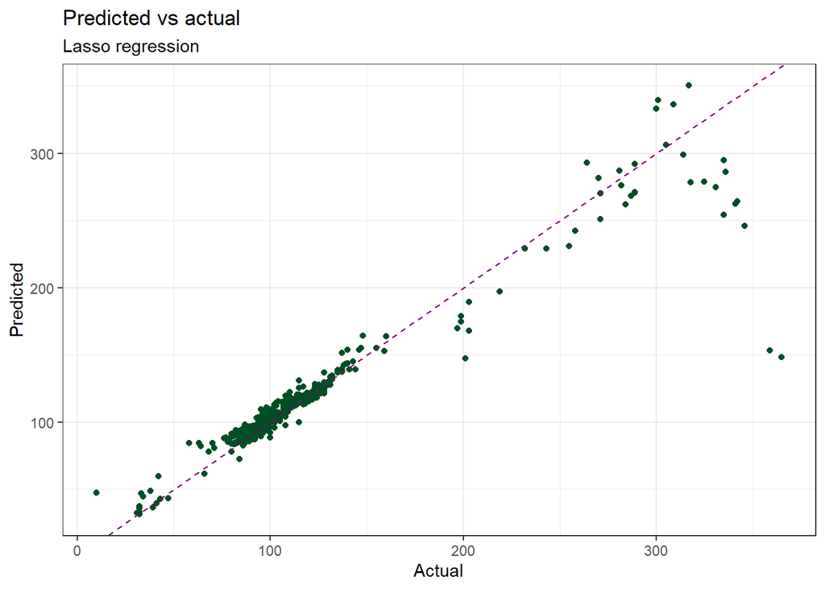

```r
ggplot() +
  geom_point(aes(x = truth_test, y = prediction_test),
             color = colors_custom[1]) +
  geom_abline(intercept = 0, slope = 1, lty = 2, color = colors_custom[2]) +
  labs(title = "Predicted vs actual",
       subtitle = "Lasso regression",
       x = "Actual",
       y = "Predicted")
```

**Variable importance**

- The importance of variables in this case is the magnitude of the coefficient, a result that is very useful since lasso regression allows to cancel predictor variables by forcing their coefficient to be zero, for this reason the variables shown in the following graph could be considered to have the greatest predictive capacity, according to this model. In this case I am taking 20% of the initial predictor variables, that is, $239 * 0.20 = 48$ predictor variables.

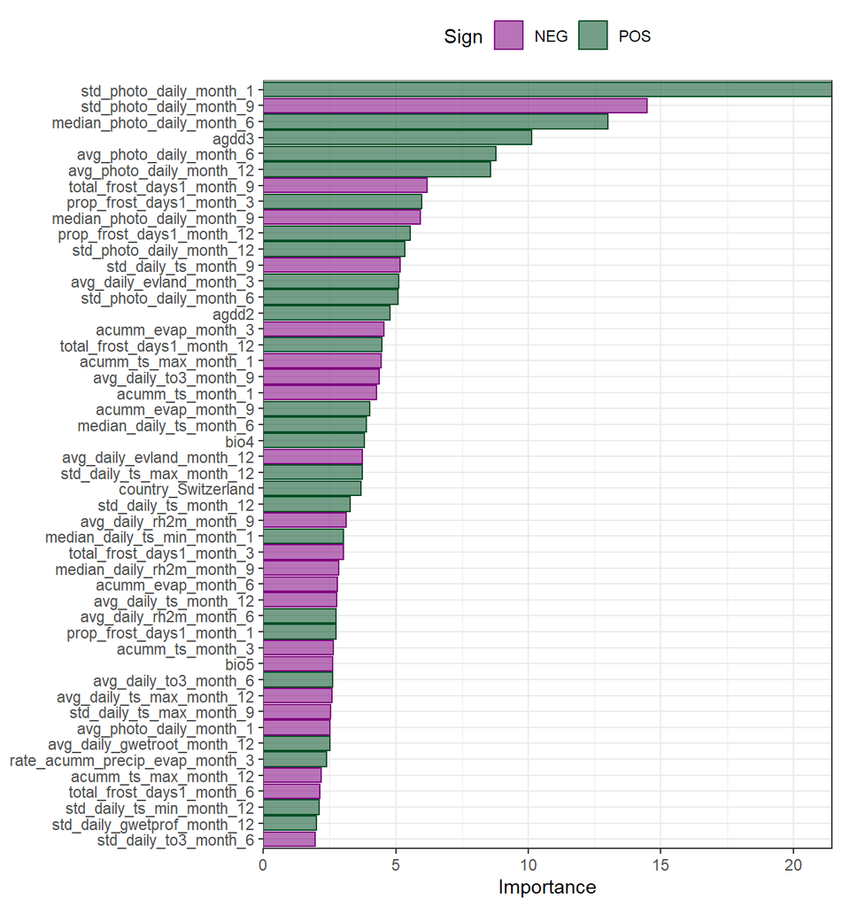

```r
library(vip)

num_vars <-  ((ncol(data_feature_sel) - 1) * 0.20) |>
  round(digits = 0)

var_importance <-
  final_model %>%
  extract_fit_parsnip() %>%
  vi() |>
  dplyr::slice(1:num_vars)

var_importance |>
  arrange(desc(Importance)) |>
  mutate(Importance = abs(Importance),
         Variable = fct_reorder(Variable, Importance)) %>%
  ggplot(aes(
    x = Importance,
    y = Variable,
    fill = Sign,
    color = Sign
  )) +
  geom_col(alpha = 0.55) +
  scale_x_continuous(expand = c(0, 0)) +
  labs(y = NULL) +
  scale_color_manual(values = c(colors_custom[2], colors_custom[1])) +
  scale_fill_manual(values = c(colors_custom[2], colors_custom[1]))
```

# XGBoost (1)

- I use the algorithm [XGBoost](https://xgboost.readthedocs.io/en/stable/) with the subset of predictor variables (48) that were the most important in the lasso model.

**Model training**

```r
# Data modeling
data_subset_xgboost <-
  data_feature_sel |>
  select(bloom_doy, lat, long, year_bloom, contains(var_importance$Variable))

# Train
data_train <-
  data_subset_xgboost |>
  group_by(lat, long) |>
  mutate(year_max = max(year_bloom, na.rm = TRUE)) |>
  ungroup() |>
  filter(year_bloom < year_max)

# Test
data_test <-
  data_subset_xgboost |>
  group_by(lat, long) |>
  mutate(year_max = max(year_bloom, na.rm = TRUE)) |>
  ungroup() |>
  filter(year_bloom == year_max)

# Split with train
set.seed(2024)
initial_split <- initial_split(data = data_train,
                               strata = "bloom_doy",
                               prop = 0.8)

train_data <- training(initial_split)
test_data <- testing(initial_split)

# Cross validation with k = 10
set.seed(2023)
folds <- vfold_cv(data = train_data,
                  strata = "bloom_doy")

# Preprocessing
recipe_doy <-
  recipe(bloom_doy ~ ., data = data_train) |>
  step_impute_median(all_numeric_predictors(), -year_bloom) |>
  step_zv(all_numeric_predictors(), -year_bloom) |>
  step_nzv(all_numeric_predictors(), -year_bloom) |>
  step_dummy(all_nominal_predictors(), one_hot = TRUE) |>
  step_YeoJohnson(all_numeric_predictors(), -year_bloom) |>
  step_normalize(all_numeric_predictors(), -year_bloom)

# Model architecture
model_xgboost <-
  boost_tree(
    tree_depth = tune(),
    learn_rate = tune(),
    loss_reduction = tune(),
    min_n = tune(),
    trees = tune(),
    mtry = tune()
  ) %>%
  set_engine("xgboost") %>%
  set_mode("regression")

# Hyperparameter grid (n = 20)
set.seed(2024)
my_grid <- grid_max_entropy(
  tree_depth(),
  learn_rate(),
  loss_reduction(),
  min_n(),
  trees(),
  finalize(mtry(), data_train),
  size = 15
)

# Modeling pipeline
my_flow <- workflow() %>%
  add_recipe(recipe_doy) %>%
  add_model(model_xgboost)

# Tuning setup
grid_ctrl <-
  control_grid(
    save_pred = TRUE,
    parallel_over = "everything",
    save_workflow = TRUE
  )

# # Fit
# doParallel::registerDoParallel()
# set.seed(2024)
# my_tuning <- tune_grid(
#   my_flow,
#   resamples = folds,
#   grid = my_grid,
#   control = grid_ctrl,
#   metrics = metric_set(mae)
# )
# doParallel::stopImplicitCluster()

# Save tuning grid xgboost
# write_rds(x = my_tuning,
#           file = "../models-trained/02-grid-tuning-xgboost.rds",
#           compress = "xz")

# Load .rds
my_tuning <- read_rds("../models-trained/02-grid-tuning-xgboost.rds")
```

**Best results**

- **Best results:** with this model the error (*MAE*) of training with resampling was 0.41 days.

```r
my_tuning %>%
  show_best(metric = "mae")
```

| mtry | trees | min_n | tree_depth | learn_rate | loss_reduction | .metric | .estimator | mean | n | std_err | .config |
| --- | --- | --- | --- | --- | --- | --- | --- | --- | --- | --- | --- |
| 42 | 784 | 8 | 6 | 0.0915175562 | 3.965564e-01 | mae | standard | 0.4112670 | 10 | 0.03161531 | Preprocessor1_Model08 |
| 43 | 431 | 24 | 13 | 0.0156887103 | 6.131357e-04 | mae | standard | 0.5700270 | 10 | 0.02619460 | Preprocessor1_Model13 |
| 33 | 1703 | 26 | 4 | 0.0146692478 | 2.974590e-02 | mae | standard | 0.6957739 | 10 | 0.02047229 | Preprocessor1_Model05 |
| 10 | 1552 | 27 | 11 | 0.0010625006 | 5.846953e+00 | mae | standard | 20.5308084 | 10 | 0.05225850 | Preprocessor1_Model12 |
| 51 | 1623 | 37 | 3 | 0.0007853176 | 1.679194e-05 | mae | standard | 29.7321886 | 10 | 0.08619536 | Preprocessor1_Model03 |

**Best model**

```r
best_model <- my_tuning %>%
  select_best(metric = "mae")

doParallel::registerDoParallel()
set.seed(2024)
model_tuned <- my_flow %>%
  finalize_workflow(best_model) %>%
  last_fit(initial_split)

doParallel::stopImplicitCluster()
```

**MAE en validation**

- This is the error in the test set (*validation*) that was used during training with resampling.

```r
prediction_validation <-
  model_tuned %>%
  collect_predictions() %>%
  pull(.pred)

truth_validation <-
  model_tuned %>%
  collect_predictions() %>%
  pull(bloom_doy)

mae_vec(truth = truth_validation, estimate = prediction_validation)
```

```
[1] 0.3393902
```

**Final model**

```r
final_model <- my_flow %>%
  finalize_workflow(best_model) %>%
  fit(bind_rows(train_data, test_data))
```

**MAE en Test**

- This is the error with data from the last flowering year of each coordinate. It is much better than the lasso model.

```r
prediction_test <-
  final_model |>
  predict(new_data = data_test) |>
  pull(.pred)

truth_test <-
  data_test %>%
  pull(bloom_doy)

mae_vec(truth = truth_test, estimate = prediction_test)
```

```
[1] 2.880395
```

**Predicted vs actual**

- The model predictions are quite approximate with a greater degree of uncertainty in late flowering, early flowering seems to predict well. Blooms above 200 exhibit high variability in model predictions.

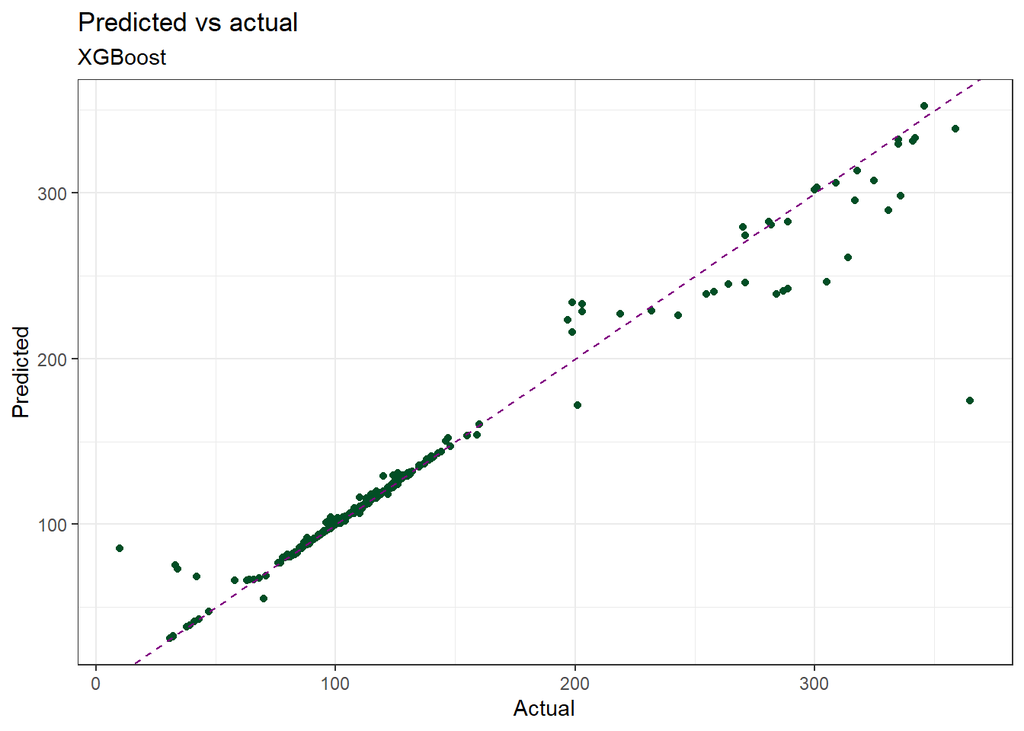

```r
ggplot() +
  geom_point(aes(x = truth_test, y = prediction_test),
             color = colors_custom[1]) +
  geom_abline(intercept = 0, slope = 1, lty = 2, color = colors_custom[2]) +
  labs(title = "Predicted vs actual",
       subtitle = "XGBoost",
       x = "Actual",
       y = "Predicted")
```

**Variable importance**

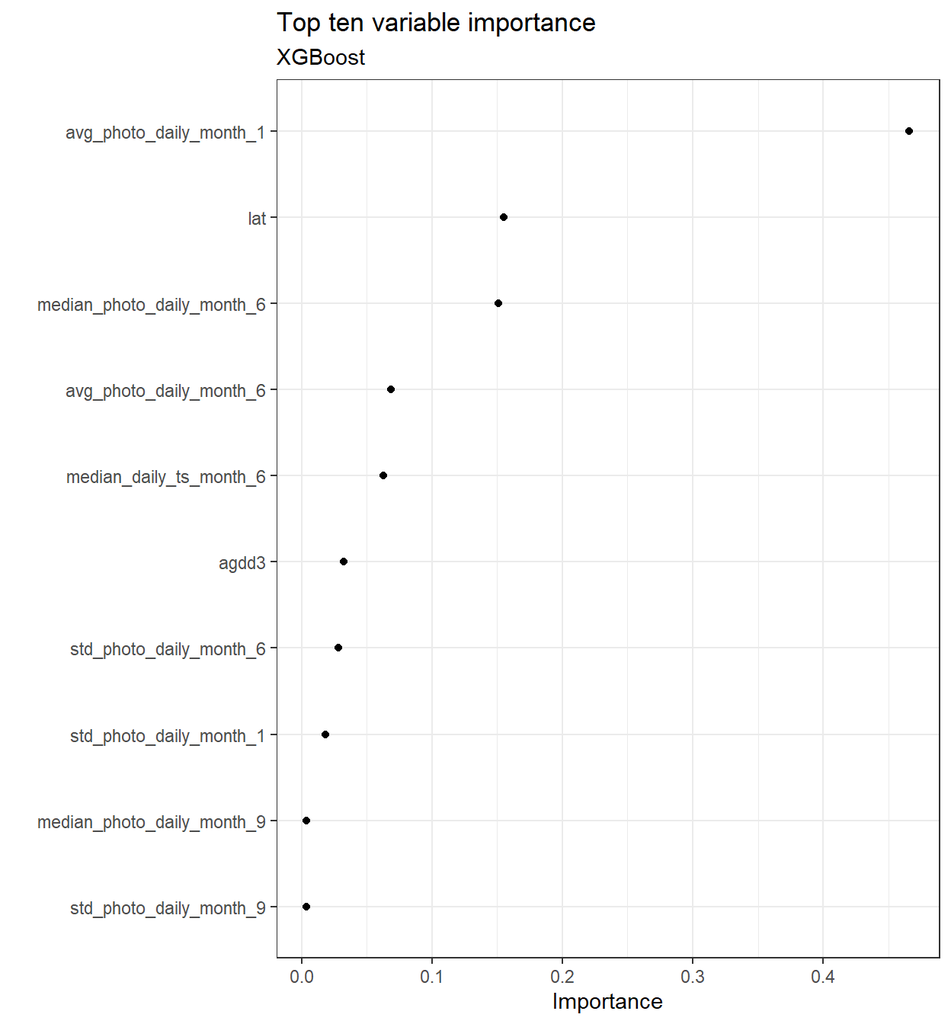

```r
library(vip)

num_vars <-  ((ncol(data_feature_sel) - 1) * 0.20) |>
  round(digits = 0)

final_model %>%
  extract_fit_parsnip() %>%
  vip(geom = "point", 10) +
  labs(title = "Top ten variable importance ",
       subtitle = "XGBoost")
```

# XGBoost (2)

- I use the [XGBoost](https://xgboost.readthedocs.io/en/stable/) algorithm with a smaller subset of variables, these variables I select based on what I observed in the exploratory analysis. In total I keep 23 predictor variables.
- In this case I am going to use the response variable transformed with a natural logarithm.

**Model training**

```r
# Data modeling
data_subset_xgboost <-
  data_feature_sel |>
  select(
    bloom_doy,
    year_bloom,
    lat,
    long,
    alt,
    contains("agdd"),
    contains("nitrogen"),
    contains("soc"),
    contains("cec"),
    bio1,
    bio12,
    bio4,
    contains("prop_frost"),
    rate_acumm_precip_evap_month_1,
    rate_acumm_precip_evap_month_3,
    rate_acumm_precip_evap_month_6,
    rate_acumm_precip_evap_month_9,
    rate_acumm_precip_evap_month_12
  ) |>
  mutate(bloom_doy = log(bloom_doy))

# Train
data_train <-
  data_subset_xgboost |>
  group_by(lat, long) |>
  mutate(year_max = max(year_bloom, na.rm = TRUE)) |>
  ungroup() |>
  filter(year_bloom < year_max) |>
  select(-year_max)

# Test
data_test <-
  data_subset_xgboost |>
  group_by(lat, long) |>
  mutate(year_max = max(year_bloom, na.rm = TRUE)) |>
  ungroup() |>
  filter(year_bloom == year_max) |>
  select(-year_max)

# Split with train
set.seed(2024)
initial_split <- initial_split(data = data_train,
                               strata = "bloom_doy",
                               prop = 0.8)

train_data <- training(initial_split)
test_data <- testing(initial_split)

# Cross validation with k = 5
set.seed(2023)
folds <- vfold_cv(data = train_data,
                  strata = "bloom_doy",
                  v = 5)

# Preprocessing
recipe_doy <-
  recipe(bloom_doy ~ ., data = data_train) |>
  step_impute_median(all_numeric_predictors(), -year_bloom) |>
  step_zv(all_numeric_predictors(), -year_bloom) |>
  step_nzv(all_numeric_predictors(), -year_bloom) |>
  step_dummy(all_nominal_predictors(), one_hot = TRUE) |>
  step_YeoJohnson(all_numeric_predictors(), -year_bloom) |>
  step_normalize(all_numeric_predictors(), -year_bloom)

# Model architecture
model_xgboost <-
  boost_tree(
    tree_depth = tune(),
    learn_rate = tune(),
    loss_reduction = tune(),
    min_n = tune(),
    trees = 1000,
    mtry = tune()
  ) %>%
  set_engine("xgboost") %>%
  set_mode("regression")

# Hyperparameter grid (n = 20)
set.seed(2024)
my_grid <- grid_max_entropy(
  tree_depth(),
  learn_rate(),
  loss_reduction(),
  min_n(),
  finalize(mtry(), data_train),
  size = 15
)

# Modeling pipeline
my_flow <- workflow() %>%
  add_recipe(recipe_doy) %>%
  add_model(model_xgboost)

# Tuning setup
grid_ctrl <-
  control_grid(
    save_pred = TRUE,
    parallel_over = "everything",
    save_workflow = TRUE
  )

# # # Fit
# doParallel::registerDoParallel()
# set.seed(2024)
# my_tuning <- tune_grid(
#   my_flow,
#   resamples = folds,
#   grid = my_grid,
#   control = grid_ctrl,
#   metrics = metric_set(mae)
# )
# doParallel::stopImplicitCluster()
#
# # Save tuning grid xgboost
# write_rds(x = my_tuning,
#           file = "../models-trained/03-grid-tuning-xgboost.rds",
#           compress = "xz")

# Load .rds
my_tuning <- read_rds("../models-trained/03-grid-tuning-xgboost.rds")
```

**Best results**

```r
my_tuning %>%
  show_best(metric = "mae")
```

| mtry | min_n | tree_depth | learn_rate | loss_reduction | .metric | .estimator | mean | n | std_err | .config |
| --- | --- | --- | --- | --- | --- | --- | --- | --- | --- | --- |
| 21 | 21 | 10 | 0.0926784753 | 8.349026e-07 | mae | standard | 0.01648975 | 5 | 0.0001282262 | Preprocessor1_Model09 |
| 14 | 21 | 3 | 0.0320971760 | 1.154883e+01 | mae | standard | 0.08943539 | 5 | 0.0006400663 | Preprocessor1_Model10 |
| 10 | 40 | 6 | 0.0011431110 | 2.160786e-07 | mae | standard | 1.32095208 | 5 | 0.0007759568 | Preprocessor1_Model07 |
| 14 | 9 | 14 | 0.0006870112 | 4.343557e-06 | mae | standard | 2.08403021 | 5 | 0.0011739790 | Preprocessor1_Model04 |
| 16 | 22 | 2 | 0.0003283021 | 6.178650e-08 | mae | standard | 2.98264614 | 5 | 0.0016798650 | Preprocessor1_Model05 |

**Best model**

```r
best_model <- my_tuning %>%
  select_best(metric = "mae")

doParallel::registerDoParallel()
set.seed(2024)
model_tuned <- my_flow %>%
  finalize_workflow(best_model) %>%
  last_fit(initial_split)

doParallel::stopImplicitCluster()
```

**MAE en validation**

```r
prediction_validation <-
  model_tuned %>%
  collect_predictions() %>%
  pull(.pred)

truth_validation <-
  model_tuned %>%
  collect_predictions() %>%
  pull(bloom_doy)

mae_vec(truth = truth_validation, estimate = prediction_validation)
```

```
[1] 0.01514643
```

**Final model**

```r
final_model <- my_flow %>%
  finalize_workflow(best_model) %>%
  fit(bind_rows(train_data, test_data))
```

**MAE en Test**

```r
prediction_test <-
  final_model |>
  predict(new_data = data_test) |>
  pull(.pred)

truth_test <-
  data_test %>%
  pull(bloom_doy)

mae_vec(truth = truth_test, estimate = prediction_test)
```

```
[1] 0.04738806
```

**Predicted vs actual**

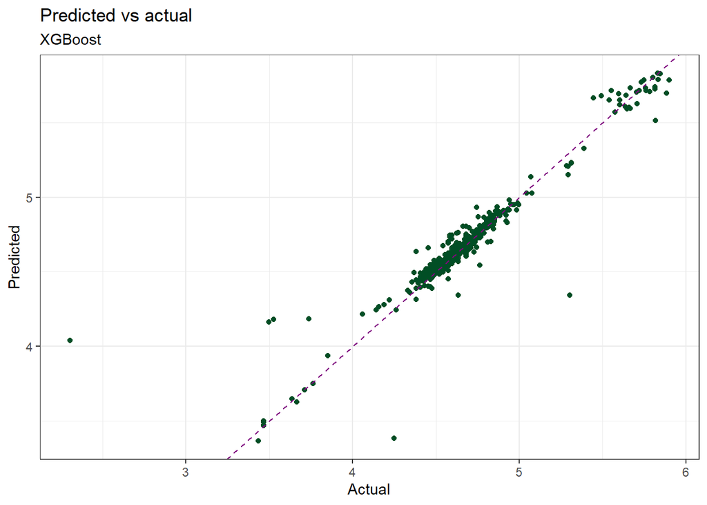

```r
ggplot() +
  geom_point(aes(x = truth_test, y = prediction_test),
             color = colors_custom[1]) +
  geom_abline(intercept = 0, slope = 1, lty = 2, color = colors_custom[2]) +
  labs(title = "Predicted vs actual",
       subtitle = "XGBoost",
       x = "Actual",
       y = "Predicted")
```

**Variable importance**

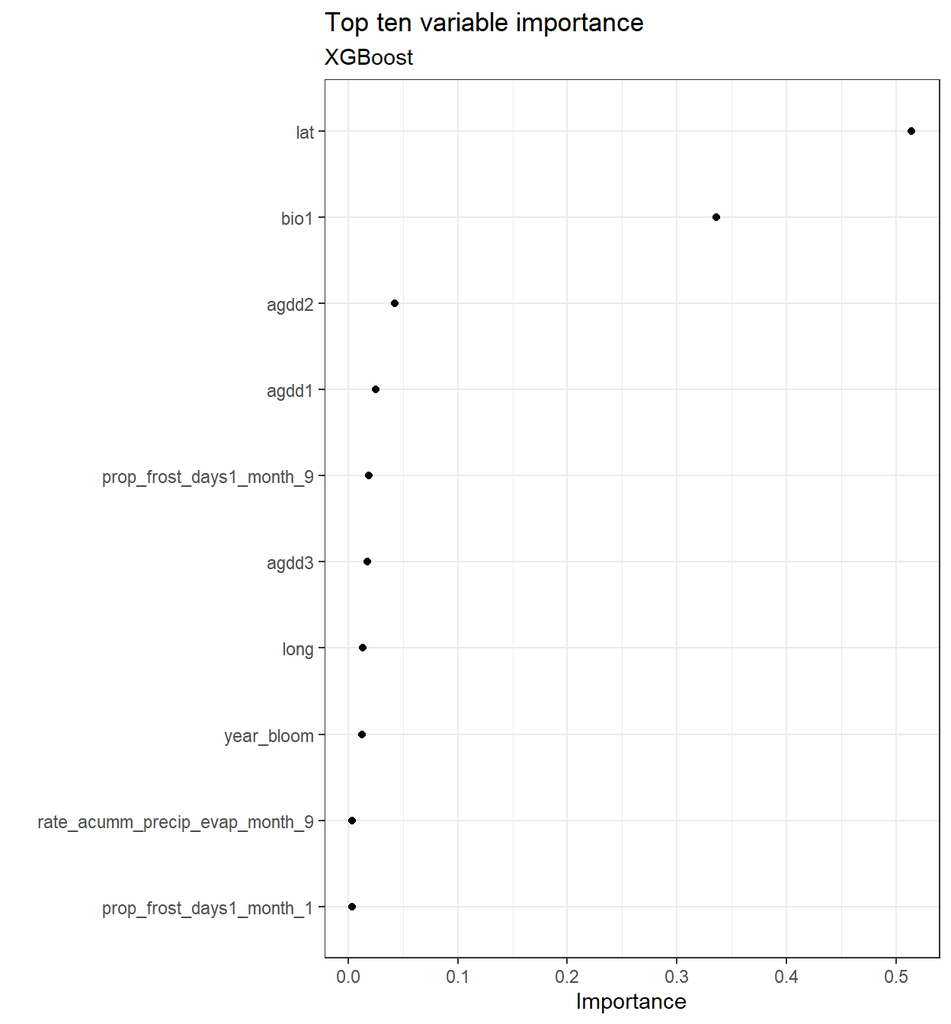

```r
library(vip)

num_vars <-  ((ncol(data_feature_sel) - 1) * 0.20) |>
  round(digits = 0)

final_model %>%
  extract_fit_parsnip() %>%
  vip(geom = "point", 10) +
  labs(title = "Top ten variable importance ",
       subtitle = "XGBoost")
```

# Predicciones 2024

- At this point I load the data for predictions for the year 2024 in the 5 coordinates of interest.
- I use the second XGBoost model to make predictions for the year 2024.

```r
data_pred_2024 <-
  read_parquet("../external-data/data-predict/data_predictors_2024.parquet")
```

- I use [resampling techniques](https://www.tidymodels.org/learn/models/conformal-regression/) to estimate the confidence intervals:

```r
library(probably)

my_flow2 <- workflow() %>%
  add_recipe(recipe_doy) %>%
  add_model(final_model$fit$fit$spec)

ctrl <- control_resamples(save_pred = TRUE, extract = I)

set.seed(2024)
folds <- vfold_cv(train_data)

doParallel::registerDoParallel()
xgb_rs <-
  my_flow2 %>%
  fit_resamples(folds, control = ctrl)
doParallel::stopImplicitCluster()


cv_int <- int_conformal_cv(xgb_rs)

final_predictions <-
  cv_int |>
  predict(new_data = data_pred_2024, level = 0.9) |>
  mutate(.pred_lower = exp(.pred_lower),
         .pred  = exp(.pred),
         .pred_upper = exp(.pred_upper))

df_pred_xgb_2024 <-
  data_pred_2024 |>
  distinct(lat, long, location) |>
  mutate(prediction = final_predictions$.pred,
         lower = final_predictions$.pred_lower,
         upper = final_predictions$.pred_upper) |>
  mutate(location = if_else(location == "NPN",
                            true = "newyorkcity",
                            false = location),
         prediction = round(prediction, digits = 0),
         lower = round(lower, digits = 0),
         upper = round(upper, digits = 0)) |>
  select(-c(lat, long))

write_csv(df_pred_xgb_2024, "../cherry-predictions.csv")

df_pred_xgb_2024 |> gt::gt()
```

| location | prediction | lower | upper |
| --- | --- | --- | --- |
| kyoto | 102 | 98 | 105 |
| liestal | 114 | 110 | 117 |
| vancouver | 97 | 94 | 100 |
| washingtondc | 106 | 103 | 110 |
| newyorkcity | 105 | 101 | 108 |

# References

- [Estimating flowering transition dates from status-based phenological observations: a test of methods](https://www.ncbi.nlm.nih.gov/pmc/articles/PMC6764363/)
- [Beyond seasonal climate: statistical estimation of phenological responses to weather](https://www.jstor.org/stable/24432272)
- [Modelling flowering of plants using time-to-event methods](https://www.sciencedirect.com/science/article/pii/S1161030109001002)
- [A model comparison for daylength as a function of latitude and day of year](https://www.sciencedirect.com/science/article/abs/pii/030438009400034F)
- [A DEMONSTRATION OF THE LAW OF THE FLOWERING PLANTS](https://realworlddatascience.net/ideas/tutorials/posts/2023/04/13/flowers.html)
- [Phenological Model to Predict Budbreak and Flowering Dates of Four Vitis vinifera L. Cultivars Cultivated in DO. Ribeiro (North-West Spain)](https://www.mdpi.com/2223-7747/10/3/502)
- [Comparison of Phenology Models for Predicting the Onset of Growing Season over the Northern Hemisphere](https://www.ncbi.nlm.nih.gov/pmc/articles/PMC4184861/)
- [The Smart Predicting of Algal Concentration for Safer Drinking Water Production with Sensor Data](https://www.mdpi.com/1424-8220/23/11/5151)
- [Chapter 21 Delineating temperature response phases with PLS regression](https://inresgb-lehre.iaas.uni-bonn.de/chillR_book/pls_intro.html)
- [Using R in hydrology: a review of recent developments and future directions](https://hess.copernicus.org/articles/23/2939/2019/)
- [PhaseR: R functions for downloading, filtering and interpolating phenological observations](https://rpubs.com/JKI-GDM/PhaseR)
- [Modeling Weed Seed Germination and Seedling Emergence](https://rpubs.com/mbmesgaran/495385)
- [Modern-Era Retrospective analysis for Research and Applications (MERRA)](https://gmao.gsfc.nasa.gov/reanalysis/MERRA/)
- [Partial least squares regression and principal component analysis: similarity and differences between two popular variable reduction approaches](https://www.ncbi.nlm.nih.gov/pmc/articles/PMC8796256/)
- [Addressing food insecurity: An exploration of wheat production expansion](https://journals.plos.org/plosone/article?id=10.1371/journal.pone.0290684#pone.0290684.e003)